# Discovering word usage differences

VU 402150 “Introduction to Computational Text Analysis with R”

Author

Affiliation

Hauke Licht

University of Innsbruck

Published

April 14, 2026

**Notea simple question**

how do groups of texts differ in their language use

- document-term count matrices provide insights into *lexical* differences $\Rightarrow$ differences in word usage **frequencies**
- word use difference statistics gives insights into **most “distinctive” terms**

**NoteMonroe et al.**

Monroe et al. ([2017](https://doi.org/10.1093/pan/mpn018))

- discuss different commonly applied statistics
- propose a new, statistically more sound one

**TipRunning example**

Differences between word usage of Labour and Convervative parties in their election manifestos

## Setup

### Load required libraries

```r
library(readr)
library(quanteda)
library(quanteda.textmodels)
library(dplyr)
library(ggplot2)
```

### Load and prepare corpus

```r
data(
    "data_corpus_ukmanifestos",
    package = "quanteda.corpora"
)
toks <- tokens(
    data_corpus_ukmanifestos,
    remove_punct=TRUE,
    remove_symbols=TRUE,
    remove_numbers=TRUE
)
toks <- tokens_remove(toks, stopwords("en"))
dtm <- dfm(toks, tolower=TRUE)
```

```r
# step 1: load corpus and prepare DTM
data("data_corpus_ukmanifestos", package = "quanteda.corpora")
toks <- tokens(
    data_corpus_ukmanifestos,
    remove_punct=TRUE,
    remove_symbols=TRUE,
    remove_numbers=TRUE
)
toks <- tokens_remove(toks, stopwords("en"))
dtm <- dfm(toks, tolower=TRUE)
```

```r
# step 2: subset to selected parties' manifestos
dtm <- dfm_subset(x = dtm, subset = docvars(dtm, "Party") %in% c("Lab", "Con")
)
```

let’s pick two parties to compare

```r
head(docvars(dtm), 3)
```

```
  Country Type Year Language Party
1      UK natl 1945       en   Con
2      UK natl 1945       en   Lab
3      UK natl 1950       en   Con
```

```r
grp_var <- "Party"
parties <- c("Lab", "Con")
# subset to selected parties' manifestos
dtm <- dfm_subset(
  x = dtm,
  subset = docvars(dtm, grp_var) %in% parties
)
```

aggregate documents at *group* level (i.e., one row per party)

```r
grouped_corp <- dfm_group(
    x = dtm,
    groups = docvars(dtm, grp_var)
)
ndoc(grouped_corp)
```

```
[1] 2
```

```r
docnames(grouped_corp)
```

```
[1] "Con" "Lab"
```

```r
grouped_corp <- grouped_corp[match(parties, docnames(grouped_corp)), ]  # ensure row order: Labour, Conservative
```

### Load helper functions

```r
source(file.path("R", "token_distinctiveness.R"))
# imports custom helper functions
# - get_top_n_terms()
# - plot_scores()
```

# 1 metrics

## Word count differences

Let’s compute “raw” word count differences:

```r
# step 1: get tokens counts matrix
tok_counts <- as.matrix(grouped_corp)
tok_counts[, 1:5]
```

```
     features
docs  conservative party mr churchill's declaration
  Lab           83   249 11           0          11
  Con          443   177 24           1          12
```

```r
# step 2: subtract counts between groups
diff_freq <- tok_counts["Lab", ] - tok_counts["Con", ]
diff_freq[1:4]
```

```
conservative        party           mr  churchill's
        -360           72          -13           -1
```

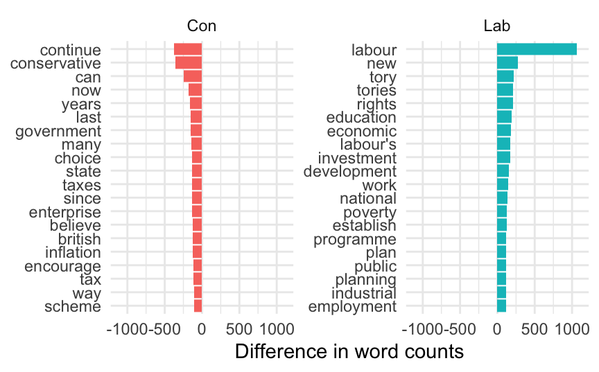

```r
stats <- get_top_n_terms(diff_freq, groups = parties)
plot_scores(x = stats, xlab = "Difference in word counts")
```

### Cons

- Does not control for total word counts (makes groups incomparable when one has more text)
- dominated by high-frequency function words (“the,” “and,” “to”) $\Rightarrow$ without additional term weighting or stopword removal, common but uninformative words dominate the top differences
- still ignores *sampling variability*

**Notesampling variability**

- word counts (and their differences) are based on a *finite* sample
- no accounting for fact that resulting metrics are noisy estimates of ‘true’ underlying word-use probabilities
- *sampling variability* is the *expected* variation in estimates if multiple samples were drawn (e.g., different documents)

## Word proportion differences

Let’s compute *relative* word use differences:

```r
# step 1: compute total tokens per group
toks_per_group <- rowSums(tok_counts)

# step 2: compute proportions per group
tok_props <- tok_counts/toks_per_group

# step 3: subtract proportions between groups
diff_prop <- tok_props["Lab", ] - tok_props["Con", ]
diff_prop[1:4]
```

```
conservative        party           mr  churchill's
  -2.529e-03    5.700e-04   -8.941e-05   -7.082e-06
```

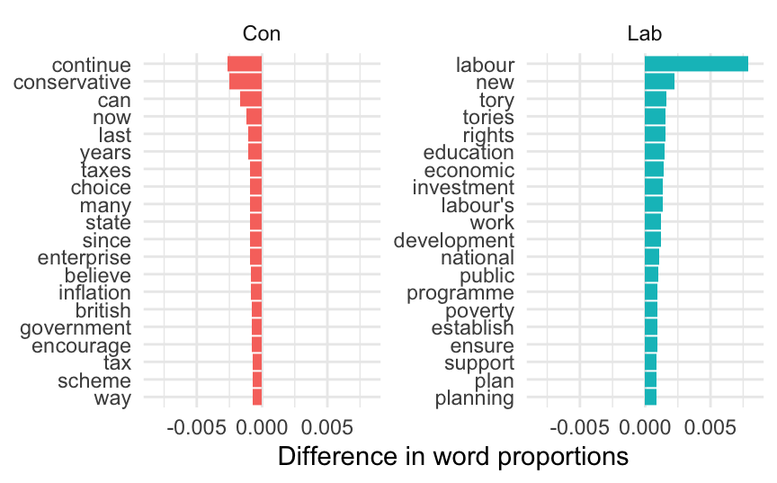

```r
stats <- get_top_n_terms(diff_prop, groups = parties)
plot_scores(x = stats, xlab = "Difference in word proportions")
```

### Pros and cons

Pros:

- Controls for total word counts
- makes groups comparable even if one has more text

Cons:

- still dominated by high-frequency function words (“the,” “and,” “to”) $\Rightarrow$ without additional term weighting or stopword removal, common but uninformative words dominate the top differences
- still ignores *sampling variability*

## Log-odds ratio

```r
# add small constant to avoid zero proportions
eps <- 1e-12
# clip proportions to avoid 0 or 1
tok_props_clipped <- pmin(pmax(tok_props, eps), 1 - eps)
# compute odds
odds <- tok_props_clipped / (1 - tok_props_clipped)
odds_ratio <- odds["Lab", ] / odds["Con", ]
log_odds <- log(odds_ratio)
log_odds[1:4]
```

```
conservative        party           mr  churchill's
     -1.6438       0.3754      -0.7467     -15.7730
```

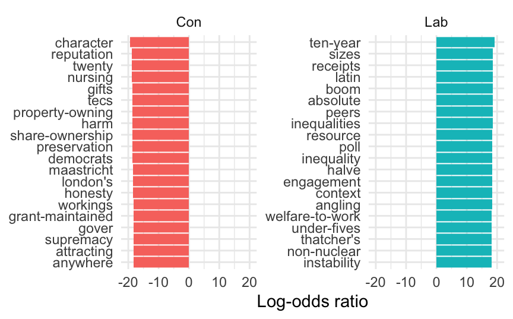

```r
stats <- get_top_n_terms(log_odds, groups = parties)
plot_scores(x = stats, xlab = "Log-odds ratio")
```

### Pros and cons

Pros:

- the log odds ratio introduces symmetry
- expresses association strength $\Rightarrow$ provides a more interpretable measure of association (“how much more likely a word is used by one group?”).

Cons:

- unstable for rare words (without smoothing)
- still ignores *sampling variability*

## Smoothed log-odds ratio

adding a small constant to counts (like 0.5) stabilize estimates for very rare words

```r
compute_logit <- function(group, e = 0.5) {
  counts <- tok_counts[group, ]
  total  <- toks_per_group[group]
  log( (counts + e) / (total - counts + e) )
}
logit_L <- compute_logit("Lab")
logit_C <- compute_logit("Con")
log_odds_smooth <- logit_L - logit_C
log_odds_smooth[1:4]
```

```
conservative        party           mr  churchill's
     -1.6389       0.3746      -0.7229      -1.0651
```

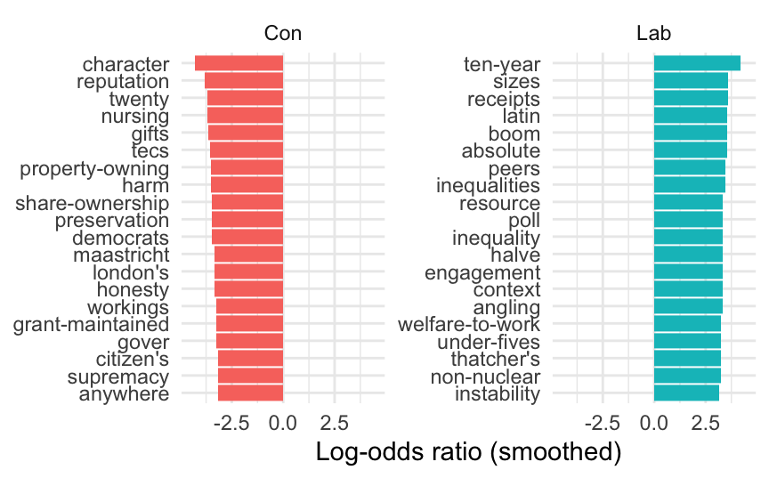

```r
stats <- get_top_n_terms(log_odds_smooth, groups = parties)
plot_scores(x = stats, xlab = "Log-odds ratio (smoothed)")
```

### Pos and cons

Pros:

- the log odds ratio introduces symmetry
- expresses association strength $\Rightarrow$ provides a more interpretable measure of association (“how much more likely a word is used by one group?”).
- smoothing introduces Dirichlet priors to shrink extreme values toward zero, avoiding division by zero and extreme values for rare words

Cons:

- still overemphasizes rare or idiosyncratic words, reducing “semantic validity”
- still ignores *sampling variability*

## Monroe et al.’s *Fightin’ Words* $z$-scores

- builds on smoothed log-odds
- incorporates an informative prior (empirical Bayes) to shrink a token’s estimates toward its overall count
- derived variance formula allows computation of *$z$-scores*
- $z>1.96$ can be considered *significantly* group-specific

## Monroe et al.’s *Fightin’ Words* $z$-scores

**Tip**

I provide an `quanteda`-compatible R implementation in file [“R/token_distinctiveness.R”](https://github.com/haukelicht/cta_intro_course/blob/main/R/token_distinctiveness.R) loaded already above

```r
# NOTE: textstat_fighting_words() provided in R/token_distinctiveness.R
fw_stats <- textstat_fighting_words(
  x = grouped_corp,
  group.var = "Party",
  .pairs = "permutations"
)
```

`fw_stats` is a list object

```r
str(fw_stats, 1)
```

```
List of 2
 $ Con-Lab:Classes 'pairwise.zscores' and 'data.frame': 23326 obs. of  8 variables:
 $ Lab-Con:Classes 'pairwise.zscores' and 'data.frame': 23326 obs. of  8 variables:
 - attr(*, "class")= chr [1:3] "pairwise.zscores" "textstat" "list"
 - attr(*, "group.var")= chr "Party"
 - attr(*, "groups")= chr [1:2] "Con" "Lab"
```

The elements are he comparison results, eg for Lab vs. Con:

```r
fw_stats[["Lab-Con"]] |>
  select(feature, z_score, Party) |>
  head(6)
```

```
       feature  z_score Party
1 conservative -13.7464   Con
2        party   3.8118   Lab
3           mr  -2.0466   Con
4  churchill's  -0.7160   Con
5  declaration  -0.1283   Con
6       policy   4.3323   Lab
```

in comparison between Labour and Conservative party manifestos

- *positive* $z$-scores $\Rightarrow$ Labour-specific terms
- *negative* $z$-scores $\Rightarrow$ Conservative-specific terms
- magnitude of $z$-score $\Rightarrow$ strength of “distinctiveness
- $|z| > 1.96$ $\Rightarrow$ statistically significant distinctiveness

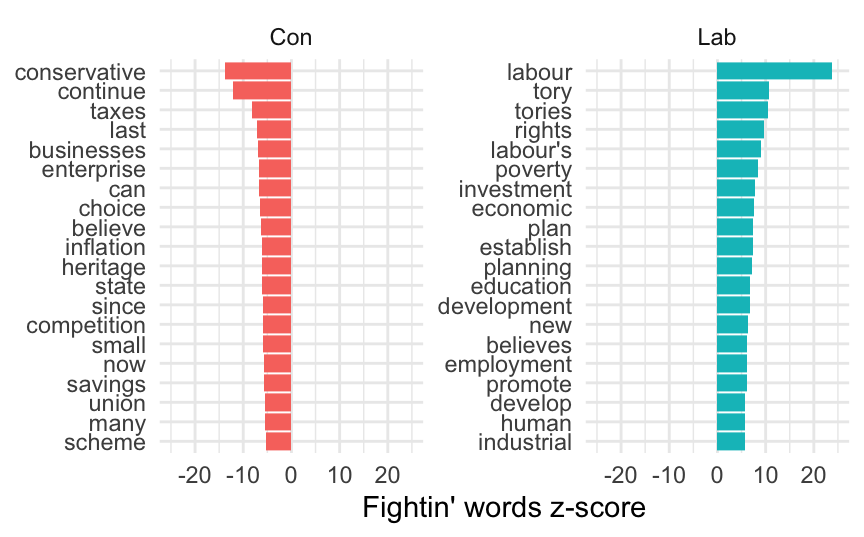

```r
top_zscores <- fw_stats[["Lab-Con"]] |>
  # for each party group
  group_by(Party) |>
  # sort from highest to lowest
  arrange(desc(abs(z_score))) |>
  # get top 20
  slice_head(n = 20) |>
  ungroup()

plot_scores(top_zscores, value.var = "z_score", group.var = "Party", xlab = "Fightin' words z-score")
```

## Pros and cons

Pros:

- combines the log odds ratio with its estimated variance
  - takes variance into account
  - provides statistical significance for differences
- produces semantically meaningful, stable results
- most robust and interpretable approach among those copmpared

Cons:

- more complex to compute
- possible overfitting or spurious high scores for very rare words if priors are weak or sample size is small